# DEM 5283/7283 Week 5: Ordinal and Multinomial Logit Models

Statistics for Demographic Data II

Author

Corey S. Sparks, PhD

Published

October 22, 2026

## Introduction

The binary logit is flexible, because almost anything can be squeezed into a yes or no. But squeezing throws information away. Self-rated health has five ordered categories, and collapsing them into “fair or poor” versus everything else treats a move from excellent to good the same as no move at all. The same is true of a political scale that runs from very liberal to very conservative, or a question with “strongly agree” through “strongly disagree.” Other outcomes have categories with no order at all: which method of contraception a woman uses, which of several labor markets a migrant moves to, how a family arranges child care, how someone gets to work. Demographers sometimes call these alternative decision-making processes, because the person (in principle) chooses one option from a set.

This week covers the two standard models for these outcomes. The **ordinal logit** (the proportional odds model) is for ordered categories, and the **multinomial logit** is for unordered ones. Both are generalizations of the binary logit, both can be fit to complex survey data, and both are much easier to explain with predicted probabilities than with coefficients. I’ll lean on predicted probabilities throughout, for the same reasons as last week.

## Setup

`svyolr()` in the `survey` package fits the proportional odds model to survey data. For the more flexible ordinal models and for the multinomial logit, the `svyVGAM` package wraps the `VGAM` package’s vector GLMs so they take a survey design.

```r
library(tidyverse)
library(here)
library(survey)
library(svyVGAM)
library(marginaleffects)
library(sparkscolors)

source(here("R", "get_mmsa.R"))
source(here("R", "recode_mmsa.R"))
source(here("R", "get_dhs_model.R"))
```

## Ordinal outcomes

### The data

I’ll use self-rated health from the 2024 BRFSS MMSA file, grouped into three ordered categories: excellent or very good, good, and fair or poor. `recode_mmsa()` creates it as an ordered factor called `genhlth3`.

```r
brfss <- get_mmsa(2024) |> recode_mmsa()
des <- svydesign(ids = ~1, strata = ~ststr, weights = ~mmsawt, data = brfss)

svymean(~genhlth3, des, na.rm = TRUE)
```

```
                               mean     SE
genhlth3Excellent/very good 0.47091 0.0023
genhlth3Good                0.34390 0.0022
genhlth3Fair/poor           0.18519 0.0018
```

### The proportional odds model

Suppose an outcome has $J$ ordered categories, and person $i$ has the response $y_i = j$ for one of $j = 1, \dots, J$. With ordered categories, it’s easier to work with the **cumulative probabilities**, $\Pr(y_i \le j)$, than with the probabilities of each category, because they increase as we move up the categories:

$$\Pr(y_i \le 1) < \Pr(y_i \le 2) < \dots < \Pr(y_i \le J) = 1$$

Since the last one is always 1, we only need to model $J - 1$ of them. The probability of any single category comes from subtracting adjacent cumulative probabilities, and the probability of the top category comes from the complement rule, $\Pr(y_i = J) = 1 - \Pr(y_i \le J - 1)$.

To connect these to a linear function of covariates, think of an unobserved, continuous health propensity $y^*$ (the same latent variable idea from last week), and suppose we only see which of $J$ intervals it falls in. The cut points between intervals are $\zeta_1 < \zeta_2 < \dots < \zeta_{J-1}$.

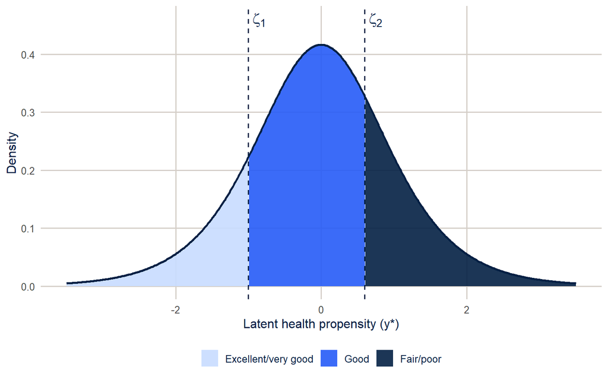

Figure 1: The latent trait model for an ordinal outcome. We observe only which interval of the unobserved propensity a person falls in; the area in each interval is the probability of that category.

```r
cuts <- c(-1, 0.6)
tibble(z = seq(-3.5, 3.5, by = 0.01), density = dlogis(z, scale = 0.6)) |>
  mutate(category = cut(z, c(-Inf, cuts, Inf),
                        labels = c("Excellent/very good", "Good", "Fair/poor"))) |>
  ggplot(aes(x = z, y = density)) +
  geom_area(aes(fill = category), alpha = 0.9) +
  geom_line(colour = utsa_cols("midnight"), linewidth = 1) +
  geom_vline(xintercept = cuts, colour = utsa_cols("midnight"), linetype = "dashed") +
  annotate("text", x = cuts, y = 0.46, label = c("zeta[1]", "zeta[2]"), parse = TRUE,
           hjust = -0.3, size = 5, colour = utsa_cols("midnight")) +
  scale_fill_manual(values = utsa_pal("blues", interpolate = TRUE)(4)[2:4]) +
  labs(x = "Latent health propensity (y*)", y = "Density", fill = NULL)
```

The proportional odds model is a set of $J-1$ binary logits for the cumulative probabilities:

$$\text{logit}\, P(y_i \le j) = \zeta_j - \mathbf{x}_i'\boldsymbol\beta, \qquad j = 1, \dots, J-1$$

Each split of the outcome gets its own intercept $\zeta_j$, but the coefficients $\boldsymbol\beta$ are the same for every split. That is the **proportional odds** (or parallel lines) assumption. It says that education, say, shifts the odds of being in a worse category by the same factor whether we’re comparing fair or poor to everything better, or good or worse to excellent or very good. With three categories there are only two splits, so the assumption is easy to look at directly.

On the log-odds scale, the assumption means the model is a set of parallel lines, one for each split, with different intercepts and the same slope.

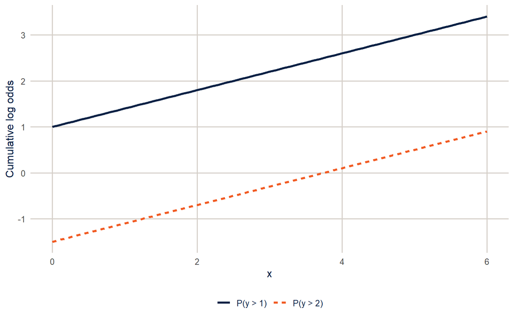

Figure 2: The proportional odds model on the log-odds scale: each cumulative split has its own intercept, but the effect of x is the same for every split.

```r
tibble(x = seq(0, 6, by = 0.1)) |>
  cross_join(tibble(split = c("P(y > 1)", "P(y > 2)"), intercept = c(1, -1.5))) |>
  mutate(log_odds = intercept + 0.4 * x) |>
  ggplot(aes(x = x, y = log_odds, colour = split, linetype = split)) +
  geom_line(linewidth = 1.2) +
  scale_colour_utsa(palette = "primary") +
  labs(x = "x", y = "Cumulative log odds", colour = NULL, linetype = NULL)
```

The model is attractive because each $\beta$ has a single, consistent interpretation. The assumption can be a weak one in practice, though, because some covariates may affect certain transitions more than others, and I’ll show how to check it below.

```r
fit_po <- svyolr(genhlth3 ~ race_eth + educ + agec + female, design = des)
summary(fit_po)
```

```
Call:
svyolr(genhlth3 ~ race_eth + educ + agec + female, design = des)

Coefficients:
                             Value Std. Error    t value
race_ethNH Black        0.39706197 0.02573562  15.428501
race_ethNH Other        0.33245344 0.03842662   8.651645
race_ethNH Multiracial  0.38059454 0.05313220   7.163162
race_ethHispanic        0.44884497 0.02765628  16.229403
educHS graduate        -0.69199477 0.04025400 -17.190708
educSome college       -0.94511797 0.04074232 -23.197450
educCollege graduate   -1.53977761 0.03922190 -39.258106
agec25-34               0.31274757 0.03581278   8.732849
agec35-44               0.40400581 0.03636483  11.109794
agec45-54               0.59404849 0.03738926  15.888211
agec55-64               0.76236943 0.03584879  21.266253
agec65+                 0.90399608 0.03361296  26.894272
female                  0.08943837 0.01773361   5.043440

Intercepts:
                         Value    Std. Error t value
Excellent/very good|Good  -0.3577   0.0495    -7.2330
Good|Fair/poor             1.3683   0.0496    27.5939
(6410 observations deleted due to missingness)
```

With the minus sign in the model, positive coefficients mean higher (here, worse) categories. Hispanic respondents have 1.57 times the odds of being in a worse health category than non-Hispanic White respondents, at any split, and college graduates have 0.21 times the odds of people without a high school diploma. The two intercepts are the cut points.

### Predicted probabilities

Odds ratios for cumulative splits are hard to explain to anyone, so I go straight to predicted probabilities. `avg_predictions()` gives the average predicted probability of each category for each level of education, holding the other variables at their observed values.

```r
po_pred <- avg_predictions(fit_po, by = "educ", wts = "(weights)")
po_pred
```

```
               Group             educ Estimate Std. Error    z Pr(>|z|)     S
 Excellent/very good Less than HS        0.223    0.01095 20.4   <0.001 304.7
 Excellent/very good HS graduate         0.404    0.01975 20.5   <0.001 307.2
 Excellent/very good Some college        0.454    0.01992 22.8   <0.001 380.1
 Excellent/very good College graduate    0.601    0.01989 30.2   <0.001 664.0
 Good                Less than HS        0.384    0.01065 36.0   <0.001 942.1
 Good                HS graduate         0.380    0.00937 40.6   <0.001   Inf
 Good                Some college        0.364    0.01062 34.3   <0.001 852.0
 Good                College graduate    0.291    0.01305 22.3   <0.001 363.3
 Fair/poor           Less than HS        0.393    0.01730 22.7   <0.001 377.1
 Fair/poor           HS graduate         0.215    0.01570 13.7   <0.001 140.0
 Fair/poor           Some college        0.182    0.01314 13.8   <0.001 142.3
 Fair/poor           College graduate    0.108    0.00860 12.6   <0.001 117.9
  2.5 % 97.5 %
 0.2019  0.245
 0.3657  0.443
 0.4152  0.493
 0.5621  0.640
 0.3628  0.405
 0.3617  0.398
 0.3431  0.385
 0.2653  0.317
 0.3590  0.427
 0.1847  0.246
 0.1561  0.208
 0.0912  0.125

Type: probs
```

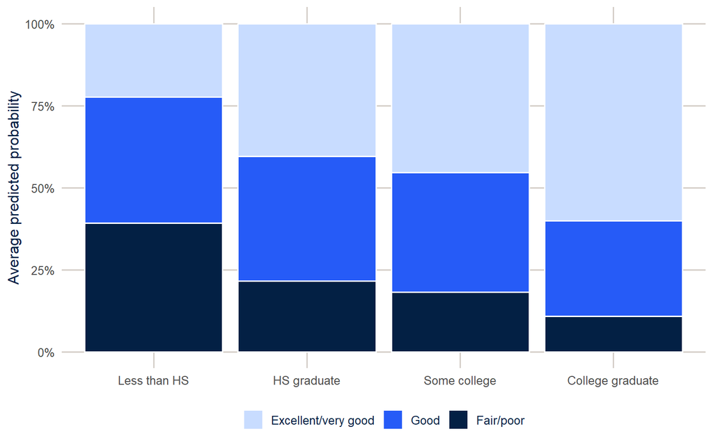

Figure 3: Average predicted probability of each self-rated health category by education, from the proportional odds model.

```r
po_pred |>
  as_tibble() |>
  mutate(group = factor(group, levels = levels(brfss$genhlth3))) |>
  ggplot(aes(x = educ, y = estimate, fill = group)) +
  geom_col(colour = "white") +
  scale_fill_manual(values = utsa_pal("blues", interpolate = TRUE)(4)[2:4]) +
  scale_y_continuous(labels = scales::label_percent()) +
  labs(x = NULL, y = "Average predicted probability", fill = NULL)
```

The model predicts that 39.3% of adults without a high school diploma report fair or poor health, compared with 10.8% of college graduates. The middle category behaves differently: the share in good health changes much less across education (38.4% versus 29.1%). That’s normal in ordinal models. The middle categories gain from one side and lose to the other, so their probabilities can move in either direction, and sometimes not at all.

**Note**

I pass `wts = "(weights)"` so the averaging uses the survey weights. The standard errors come from the design-based variance of the coefficients through the delta method.

### Checking the proportional odds assumption

A simple first look is to fit the binary logits for each split separately and compare the coefficients. This isn’t a formal test, but if the assumption holds, the two sets of coefficients should be close.

```r
split1 <- svyglm(I(genhlth3 >= "Good") ~ race_eth + educ + agec + female,
                 design = des, family = quasibinomial())
split2 <- svyglm(I(genhlth3 == "Fair/poor") ~ race_eth + educ + agec + female,
                 design = des, family = quasibinomial())
```

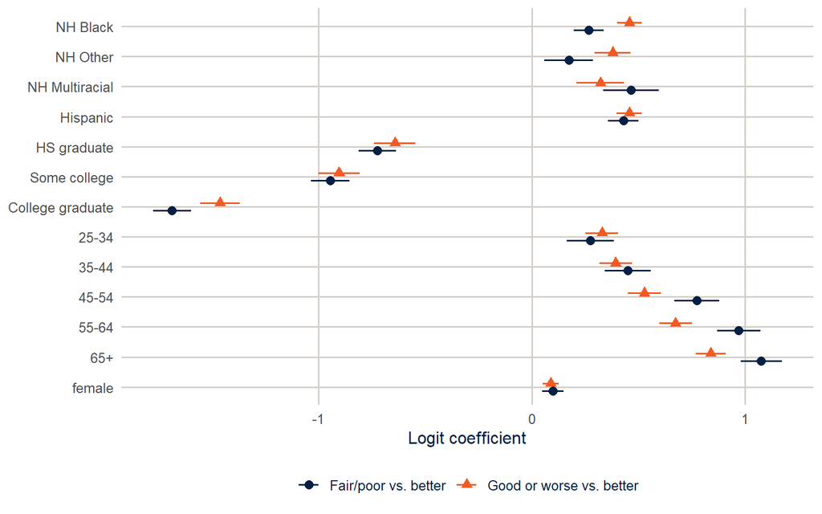

Figure 4: Coefficients from separate logits for the two splits of self-rated health. Under proportional odds they should be about equal.

```r
list("Good or worse vs. better" = split1, "Fair/poor vs. better" = split2) |>
  map(\(m) broom::tidy(m, conf.int = TRUE)) |>
  list_rbind(names_to = "split") |>
  filter(term != "(Intercept)") |>
  mutate(term = str_remove_all(term, "race_eth|educ|agec"),
         term = fct_inorder(term)) |>
  ggplot(aes(x = estimate, y = fct_rev(term), colour = split, shape = split)) +
  geom_vline(xintercept = 0, colour = utsa_cols("smoke")) +
  geom_pointrange(aes(xmin = conf.low, xmax = conf.high),
                  position = position_dodge(width = 0.5)) +
  scale_colour_utsa(palette = "primary") +
  labs(x = "Logit coefficient", y = NULL, colour = NULL, shape = NULL)
```

Most coefficients are close. Age is the exception: the older age groups have larger coefficients for the fair or poor split than for the good or worse split. In other words, getting older is associated with a bigger increase in the odds of fair or poor health than in the odds of merely good health.

### Relaxing the assumption

`svy_vglm()` fits cumulative logit models in which some or all of the coefficients are allowed to differ across splits. The `parallel` argument controls which ones: `parallel = TRUE` is the proportional odds model, `parallel = FALSE` lets everything vary, and `parallel = FALSE ~ agec` lets only age vary. That last one is the **partial proportional odds** model.

```r
fit_vpo <- svy_vglm(genhlth3 ~ race_eth + educ + agec + female, design = des,
                    family = cumulative(parallel = TRUE, reverse = TRUE))
fit_ppo <- svy_vglm(genhlth3 ~ race_eth + educ + agec + female, design = des,
                    family = cumulative(parallel = FALSE ~ agec, reverse = TRUE))
summary(fit_ppo)
```

```
svy_vglm.survey.design(genhlth3 ~ race_eth + educ + agec + female,
    design = des, family = cumulative(parallel = FALSE ~ agec,
        reverse = TRUE))
Stratified Independent Sampling design (with replacement)
svydesign(ids = ~1, strata = ~ststr, weights = ~mmsawt, data = brfss)
                            Coef        SE        z         p
(Intercept):1           0.380494  0.050327   7.5604 4.019e-14
(Intercept):2          -1.462412  0.057373 -25.4897 < 2.2e-16
race_ethNH Black        0.392659  0.025979  15.1143 < 2.2e-16
race_ethNH Other        0.329108  0.039105   8.4160 < 2.2e-16
race_ethNH Multiracial  0.378044  0.052229   7.2383 4.544e-13
race_ethHispanic        0.448803  0.027546  16.2930 < 2.2e-16
educHS graduate        -0.690490  0.040034 -17.2476 < 2.2e-16
educSome college       -0.942399  0.040429 -23.3101 < 2.2e-16
educCollege graduate   -1.534704  0.038969 -39.3824 < 2.2e-16
agec25-34:1             0.333797  0.038917   8.5771 < 2.2e-16
agec25-34:2             0.254770  0.055389   4.5996 4.233e-06
agec35-44:1             0.404636  0.039483  10.2483 < 2.2e-16
agec35-44:2             0.421310  0.053923   7.8132 5.577e-15
agec45-54:1             0.545899  0.039984  13.6530 < 2.2e-16
agec45-54:2             0.735997  0.053068  13.8690 < 2.2e-16
agec55-64:1             0.690467  0.038861  17.7676 < 2.2e-16
agec55-64:2             0.938734  0.050549  18.5709 < 2.2e-16
agec65+:1               0.841956  0.036064  23.3459 < 2.2e-16
agec65+:2               1.055013  0.047935  22.0091 < 2.2e-16
female                  0.090197  0.017744   5.0832 3.711e-07
```

`VGAM` writes the model as $\text{logit}\, P(y \ge j+1) = \alpha_j + \mathbf{x}'\boldsymbol\beta$ when `reverse = TRUE`, so the slopes have the same sign as in `svyolr()` and the intercepts have the opposite sign. The age coefficients now come in pairs, with `:1` for the first split and `:2` for the second.

To test whether age needs separate coefficients, I use a design-based Wald test that the pairs are equal. `svy_vglm()` stores the coefficients and their design-based covariance matrix, so the test only takes a contrast matrix.

```r
b <- fit_ppo$coef
V <- fit_ppo$var
age_terms <- unique(str_remove(grep("^agec", names(b), value = TRUE), ":[12]$"))

L <- matrix(0, nrow = length(age_terms), ncol = length(b),
            dimnames = list(age_terms, names(b)))
for (a in age_terms) {
  L[a, paste0(a, ":1")] <- 1
  L[a, paste0(a, ":2")] <- -1
}

diffs <- L %*% b
wald <- drop(t(diffs) %*% solve(L %*% V %*% t(L)) %*% diffs)
c(chisq = wald, df = nrow(L),
  p = pchisq(wald, df = nrow(L), lower.tail = FALSE))
```

```
       chisq           df            p
9.287146e+01 5.000000e+00 1.674219e-18
```

The test rejects equality, so the partial proportional odds model is the better description of these data. Is the difference big enough to matter? In a sample of this size, almost any departure from proportional odds will be “significant,” so look at the coefficients too. The race, education and sex effects barely move between the two models, which tells you the substantive conclusions about them don’t depend on the assumption.

**Tip**

You’ll see the Brant test recommended for checking proportional odds. It’s a fine test for simple random samples, but it doesn’t account for survey design, and the Wald test above does. You’ll also see people compare pseudo-AIC values computed from survey models. Weighted pseudo-likelihoods aren’t true likelihoods, so I don’t trust AIC comparisons built on them.

## Unordered outcomes

### The multinomial logit model

The natural distribution for an outcome with $J$ unordered categories is the multivariate extension of the binomial, the **multinomial**. If $\pi_1, \pi_2, \dots, \pi_J$ are the probabilities of the categories (with $\sum_j \pi_j = 1$), and we observe $y_1$ outcomes in the first category, $y_2$ in the second and so on, with $\sum_j y_j = n$, then

$$f(\mathbf{y} \mid n) = \frac{n!}{y_1!\, y_2! \cdots y_J!}\, \pi_1^{y_1} \pi_2^{y_2} \cdots \pi_J^{y_J}$$

With $J = 2$ this is just the binomial. For an individual respondent, $n = 1$, and one of the $y_j$ is 1 and the rest are 0.

When the categories have no natural order, we pick one as the reference and model the log odds of each other category relative to it. With $J$ categories there are $J-1$ equations, each with its own set of coefficients:

$$\log \frac{P(y_i = j)}{P(y_i = \text{ref})} = \mathbf{x}_i'\boldsymbol\beta_j, \qquad j \ne \text{ref}$$

and the probabilities come from putting them back together:

$$P(y_i = j) = \frac{\exp(\mathbf{x}_i'\boldsymbol\beta_j)}{\sum_{k} \exp(\mathbf{x}_i'\boldsymbol\beta_k)}, \qquad \boldsymbol\beta_{\text{ref}} = \mathbf{0}$$

That’s a lot of coefficients. With three categories every predictor gets two of them, and the exponentiated coefficients (relative risk ratios) compare each category to the reference, not to “everything else.” Predicted probabilities are even more important here than in the ordinal model.

The multinomial logit also assumes the **independence of irrelevant alternatives** (IIA): the odds of choosing A over B don’t depend on whether C is available. Formal tests for IIA perform poorly, so the practical advice is to think about whether your categories are distinct alternatives that people actually choose among, and to avoid near-duplicate categories (Long and Freese 2014).

### The data: contraceptive use and intentions

I’ll use the DHS model dataset again, now for currently married or cohabiting women. DHS asks women who aren’t using contraception whether they intend to use it later, which gives three categories: using a method, not using but intending to, and not using with no intention to.

```r
dhs <- get_dhs_model() |>
  filter(v502 == 1) |>
  mutate(fp = factor(case_when(v364 %in% 1:2 ~ "Using",
                               v364 == 3 ~ "Intends to use",
                               v364 == 4 ~ "No intention"),
                     levels = c("Using", "Intends to use", "No intention")),
         age = v012,
         children = v218,
         educ = factor(v106, 0:3, c("None", "Primary", "Secondary", "Higher")),
         wealth = factor(v190, 1:5, c("Poorest", "Poorer", "Middle", "Richer", "Richest")),
         rural = factor(v025, 1:2, c("Urban", "Rural")),
         wt = v005 / 1e6)

table(dhs$educ, dhs$fp)
```

```
            Using Intends to use No intention
  None        552           1492         1821
  Primary     126            326          223
  Secondary   178            367          191
  Higher       37             35           32
```

The DHS design has clusters (`v021`), strata (`v022`), and a weight (`v005`) with six implied decimal places. Cluster numbers repeat across strata, so `nest = TRUE`.

```r
dhs_des <- svydesign(ids = ~v021, strata = ~v022, weights = ~wt,
                     data = dhs, nest = TRUE)
svymean(~fp, dhs_des)
```

```
                    mean     SE
fpUsing          0.17539 0.0092
fpIntends to use 0.40244 0.0120
fpNo intention   0.42217 0.0146
```

### Fitting the model

```r
fit_mn <- svy_vglm(fp ~ age + I(age^2) + children + educ + wealth + rural,
                   design = dhs_des,
                   family = multinomial(refLevel = "Using"))
summary(fit_mn)
```

```
svy_vglm.survey.design(fp ~ age + I(age^2) + children + educ +
    wealth + rural, design = dhs_des, family = multinomial(refLevel = "Using"))
Stratified 1 - level Cluster Sampling design (with replacement)
With (217) clusters.
svydesign(ids = ~v021, strata = ~v022, weights = ~wt, data = dhs,
    nest = TRUE)
                       Coef          SE       z         p
(Intercept):1    4.16005594  0.83742642  4.9677 6.776e-07
(Intercept):2    5.75696831  0.82464201  6.9812 2.927e-12
age:1           -0.16637316  0.05353515 -3.1077 0.0018853
age:2           -0.31261649  0.04876549 -6.4106 1.449e-10
I(age^2):1       0.00197825  0.00076557  2.5840 0.0097660
I(age^2):2       0.00542811  0.00070425  7.7076 1.282e-14
children:1      -0.11482843  0.03169620 -3.6228 0.0002915
children:2      -0.28354062  0.03263935 -8.6871 < 2.2e-16
educPrimary:1   -0.10879839  0.14510697 -0.7498 0.4533869
educPrimary:2   -0.49198840  0.16162089 -3.0441 0.0023339
educSecondary:1 -0.31340581  0.18143318 -1.7274 0.0840977
educSecondary:2 -0.95435598  0.21676772 -4.4027 1.069e-05
educHigher:1    -0.90189534  0.27620173 -3.2654 0.0010933
educHigher:2    -1.75201979  0.44976266 -3.8954 9.802e-05
wealthPoorer:1   0.02863509  0.15059989  0.1901 0.8491993
wealthPoorer:2  -0.03069719  0.14734460 -0.2083 0.8349666
wealthMiddle:1   0.05917347  0.16179329  0.3657 0.7145628
wealthMiddle:2  -0.05046086  0.16054973 -0.3143 0.7532928
wealthRicher:1  -0.11387436  0.17081414 -0.6667 0.5049916
wealthRicher:2  -0.45115850  0.20114309 -2.2430 0.0248986
wealthRichest:1 -0.13174172  0.22141239 -0.5950 0.5518394
wealthRichest:2 -0.07560169  0.26970612 -0.2803 0.7792386
ruralRural:1     0.56907897  0.14304058  3.9784 6.937e-05
ruralRural:2     0.77513298  0.18115153  4.2789 1.878e-05
```

Each coefficient ending in `:1` belongs to the equation for “intends to use” versus “using,” and each ending in `:2` belongs to “no intention” versus “using.” Rural women have 2.17 times the relative risk of having no intention to use (rather than using) compared with urban women, holding the other variables constant. Secondary education is associated with lower relative risks of both non-use categories, and much more so for no intention (0.39) than for intending to use (0.73).

### Predicted probabilities

`svy_vglm()` keeps the underlying `vglm` fit in `$fit`, and its `predict()` method returns the probability of each category. To get the average predicted probability for each level of education, I set every woman’s education to that level, predict, and take the weighted average. These are the same counterfactual averages that `avg_predictions()` computes, done by hand.

```r
mn_pred <- levels(dhs$educ) |>
  set_names() |>
  map(\(e) {
    nd <- mutate(dhs, educ = factor(e, levels = levels(dhs$educ)))
    p <- predict(fit_mn$fit, newdata = nd, type = "response")
    tibble(outcome = colnames(p),
           probability = colSums(p * dhs$wt) / sum(dhs$wt))
  }) |>
  list_rbind(names_to = "educ") |>
  mutate(educ = factor(educ, levels = levels(dhs$educ)),
         outcome = factor(outcome, levels = levels(dhs$fp)))

mn_pred |>
  pivot_wider(names_from = outcome, values_from = probability) |>
  knitr::kable(digits = 3)
```

| educ | Using | Intends to use | No intention |
| --- | --- | --- | --- |
| None | 0.152 | 0.385 | 0.464 |
| Primary | 0.191 | 0.438 | 0.371 |
| Secondary | 0.241 | 0.454 | 0.305 |
| Higher | 0.372 | 0.403 | 0.225 |

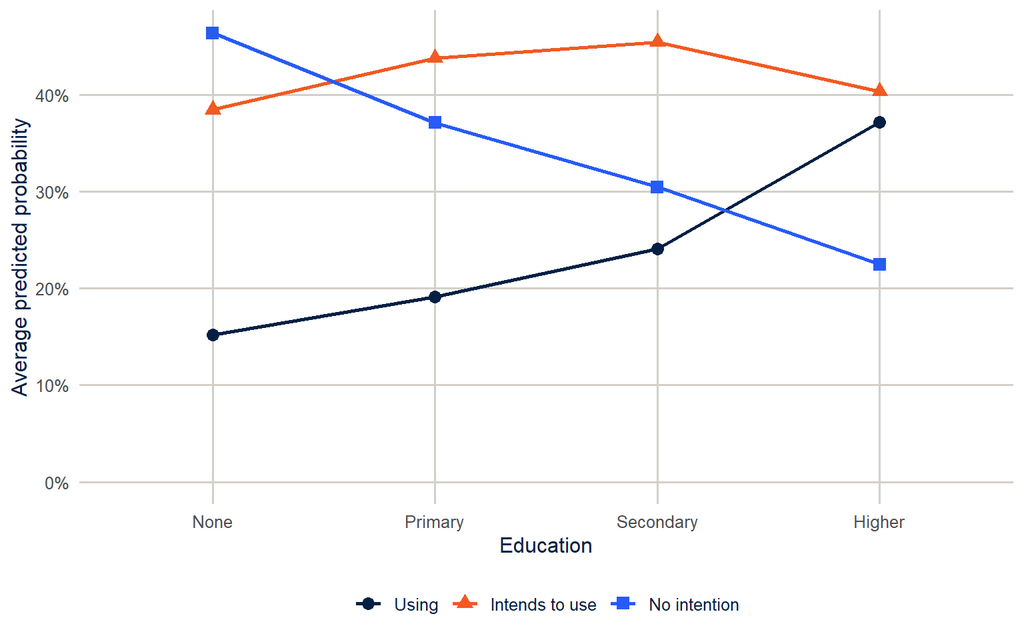

Figure 5: Average predicted probabilities of contraceptive use and intention by education, married and cohabiting women, DHS model data.

```r
mn_pred |>
  ggplot(aes(x = educ, y = probability, colour = outcome, group = outcome,
             shape = outcome)) +
  geom_line(linewidth = 1) +
  geom_point(size = 3) +
  scale_colour_utsa() +
  scale_y_continuous(labels = scales::label_percent(), limits = c(0, NA)) +
  labs(x = "Education", y = "Average predicted probability",
       colour = NULL, shape = NULL)
```

The picture is clearer than the table of coefficients. Moving from no education to higher education, the predicted probability of using a method rises from 15.2% to 37.2%, and the probability of having no intention to use falls from 46.4% to 22.5%. The intending-to-use category changes much less (it rises a little and then falls), because what it gains from “no intention” it loses to “using.” That’s the kind of pattern a binary model of use versus non-use would hide.

One caution: only 104 women in the sample have higher education, so the estimates for that group are much less precise than the others.

**Warning**

These predicted probabilities don’t come with standard errors. `nnet::multinom()` with `marginaleffects` will give you standard errors, but they treat the weights as if the data were a simple random sample, and with clustered DHS data they are much too small. For design-based intervals on predicted probabilities, repeat the calculation over replicate weights (exercise 3).

## Back to self-rated health: ordered or not?

Nothing stops us from fitting a multinomial model to an ordered outcome. It just ignores the ordering, and it spends a lot more parameters doing so: two full sets of coefficients instead of one set plus two cut points. Comparing it with the ordinal models is a useful check on how much the proportional odds structure is costing us.

```r
brfss_mn <- brfss |>
  mutate(genhlth_u = factor(genhlth3, ordered = FALSE))
des_mn <- svydesign(ids = ~1, strata = ~ststr, weights = ~mmsawt, data = brfss_mn)

fit_srh_mn <- svy_vglm(genhlth_u ~ race_eth + educ + agec + female, design = des_mn,
                       family = multinomial(refLevel = "Excellent/very good"))

round(exp(fit_srh_mn$coef[grep("^educ|^race_ethHispanic", names(fit_srh_mn$coef))]), 2)
```

```
    race_ethHispanic:1     race_ethHispanic:2      educHS graduate:1
                  1.47                   1.84                   0.68
     educHS graduate:2     educSome college:1     educSome college:2
                  0.39                   0.54                   0.28
educCollege graduate:1 educCollege graduate:2
                  0.36                   0.11
```

Here the reference category is excellent or very good health, so every coefficient ending in `:1` compares good health with excellent or very good, and every one ending in `:2` compares fair or poor health with excellent or very good. College graduates have 0.36 times the relative risk of good (rather than excellent or very good) health compared with adults who didn’t finish high school, and 0.11 times the relative risk of fair or poor health. Education matters for both comparisons, and much more for the second. That’s the same thing the split logits showed us, seen from a different angle.

The way to compare the three models is through their predicted probabilities. I use the same set-everyone’s-education-and-average approach as for the DHS model, on the respondents used to fit the models.

```r
srh_cc <- brfss_mn |>
  filter(complete.cases(genhlth_u, race_eth, educ, agec, female))

avg_probs <- function(fit, data) {
  levels(data$educ) |>
    set_names() |>
    map(\(e) {
      nd <- mutate(data, educ = factor(e, levels = levels(data$educ)))
      p <- predict(fit, newdata = nd, type = "response")
      tibble(outcome = colnames(p),
             probability = colSums(p * data$mmsawt) / sum(data$mmsawt))
    }) |>
    list_rbind(names_to = "educ")
}

srh_pred <- list("Proportional odds" = fit_vpo$fit,
                 "Partial proportional odds" = fit_ppo$fit,
                 "Multinomial" = fit_srh_mn$fit) |>
  map(\(f) avg_probs(f, srh_cc)) |>
  list_rbind(names_to = "model") |>
  mutate(model = fct_inorder(model),
         educ = factor(educ, levels = levels(brfss$educ)),
         outcome = factor(outcome, levels = levels(brfss$genhlth3)))

srh_pred |>
  pivot_wider(names_from = model, values_from = probability) |>
  arrange(outcome, educ) |>
  knitr::kable(digits = 3)
```

| educ | outcome | Proportional odds | Partial proportional odds | Multinomial |
| --- | --- | --- | --- | --- |
| Less than HS | Excellent/very good | 0.249 | 0.249 | 0.262 |
| HS graduate | Excellent/very good | 0.394 | 0.395 | 0.396 |
| Some college | Excellent/very good | 0.454 | 0.455 | 0.459 |
| College graduate | Excellent/very good | 0.598 | 0.598 | 0.594 |
| Less than HS | Good | 0.392 | 0.394 | 0.368 |
| HS graduate | Good | 0.384 | 0.384 | 0.381 |
| Some college | Good | 0.364 | 0.363 | 0.354 |
| College graduate | Good | 0.292 | 0.291 | 0.306 |
| Less than HS | Fair/poor | 0.360 | 0.357 | 0.370 |
| HS graduate | Fair/poor | 0.222 | 0.221 | 0.223 |
| Some college | Fair/poor | 0.182 | 0.182 | 0.188 |
| College graduate | Fair/poor | 0.110 | 0.110 | 0.100 |

## Exercises

These exercises are Homework 5.

**1.** Fit the proportional odds model for `genhlth3` with income (`income`) added. Use `avg_predictions()` to get the predicted probability of each health category by income group, and describe the pattern in two or three sentences.

```r
# YOUR CODE HERE
```

**2.** Use the five-category version of self-rated health (`genhlth`, codes 1 to 5) as an ordered factor. Fit the proportional odds model and the model with `parallel = FALSE` for all variables. Which variables seem to violate proportional odds? Use the Wald test approach from this document.

```r
# YOUR CODE HERE
```

**3.** Convert the DHS design to a bootstrap replicate design with `as.svrepdesign(dhs_des, type = "bootstrap", replicates = 100)`. Write a function that fits the multinomial model with a given set of weights and returns the average predicted probability of “Using” for women with no education and with secondary education. Run it over the replicate weights and report a standard error for each.

```r
# YOUR CODE HERE
```

**A hint for exercise 3**

`VGAM::vglm()` takes a `weights` argument, and `vglm(..., weights = w)` gives the same point estimates as `svy_vglm()` when `w` is the design weight. Loop over the columns of `weights(rep_des, "analysis")`, collect the two probabilities from each replicate, and pass the matrix of replicate estimates to `svrVar()` along with the design’s `scale`, `rscales` and the full-sample estimates.

**4.** Re-fit the multinomial model with “No intention” as the reference category. Show that the predicted probabilities don’t change, and explain in a sentence why the coefficients do.

```r
# YOUR CODE HERE
```

## References

Long, J. Scott, and Jeremy Freese. 2014. *Regression Models for Categorical Dependent Variables Using Stata*. 3rd ed. Stata Press.